# Example of SEM in the ‘Real World’

Michael Hallquist

26 Mar 2019

These are data from a clinical interview of personality pathology in a large mixed group of participants assessed in Pittsburgh (PI: Paul Pilkonis). We have 0/1/2 (absent, subthreshold, present) for diagnostic criteria of 10 DSM-IV personality disorders.

```r
load("pdsymptoms_for_sem.RData")
psych::describe(allPD)
```

|  | vars | n | mean | sd | median | trimmed | mad | min | max | range | skew | kurtosis | se |
| --- | --- | --- | --- | --- | --- | --- | --- | --- | --- | --- | --- | --- | --- |
| PTNUM | 1 | 445 | 4616.052 | 2363.311 | 5082 | 4707.655 | 2987.4 | 1004 | 9011 | 8007 | -0.297 | -1.389 | 112.032 |
| Par_1 | 2 | 445 | 0.151 | 0.411 | 0 | 0.039 | 0.0 | 0 | 2 | 2 | 2.777 | 7.341 | 0.019 |
| Par_2 | 3 | 445 | 0.231 | 0.518 | 0 | 0.109 | 0.0 | 0 | 2 | 2 | 2.178 | 3.822 | 0.025 |
| Par_3 | 4 | 445 | 0.178 | 0.458 | 0 | 0.059 | 0.0 | 0 | 2 | 2 | 2.603 | 6.130 | 0.022 |
| Par_4 | 5 | 445 | 0.256 | 0.559 | 0 | 0.120 | 0.0 | 0 | 2 | 2 | 2.081 | 3.199 | 0.027 |
| Par_5 | 6 | 445 | 0.294 | 0.590 | 0 | 0.157 | 0.0 | 0 | 2 | 2 | 1.854 | 2.239 | 0.028 |
| Par_6 | 7 | 445 | 0.171 | 0.472 | 0 | 0.039 | 0.0 | 0 | 2 | 2 | 2.796 | 6.974 | 0.022 |
| Par_7 | 8 | 445 | 0.052 | 0.268 | 0 | 0.000 | 0.0 | 0 | 2 | 2 | 5.625 | 33.143 | 0.013 |
| Schizoid_1 | 9 | 445 | 0.029 | 0.181 | 0 | 0.000 | 0.0 | 0 | 2 | 2 | 6.660 | 48.514 | 0.009 |
| Schizoid_2 | 10 | 445 | 0.130 | 0.426 | 0 | 0.000 | 0.0 | 0 | 2 | 2 | 3.368 | 10.653 | 0.020 |
| Schizoid_3 | 11 | 445 | 0.117 | 0.402 | 0 | 0.000 | 0.0 | 0 | 2 | 2 | 3.587 | 12.361 | 0.019 |
| Schizoid_4 | 12 | 445 | 0.025 | 0.169 | 0 | 0.000 | 0.0 | 0 | 2 | 2 | 7.431 | 60.895 | 0.008 |
| Schizoid_5 | 13 | 445 | 0.198 | 0.546 | 0 | 0.036 | 0.0 | 0 | 2 | 2 | 2.642 | 5.527 | 0.026 |
| Schizoid_6 | 14 | 445 | 0.013 | 0.115 | 0 | 0.000 | 0.0 | 0 | 1 | 1 | 8.408 | 68.856 | 0.005 |
| Schizoid_7 | 15 | 445 | 0.045 | 0.228 | 0 | 0.000 | 0.0 | 0 | 2 | 2 | 5.462 | 32.307 | 0.011 |
| Schizotypal_1 | 16 | 445 | 0.027 | 0.162 | 0 | 0.000 | 0.0 | 0 | 1 | 1 | 5.821 | 31.953 | 0.008 |
| Schizotypal_2 | 17 | 445 | 0.065 | 0.273 | 0 | 0.000 | 0.0 | 0 | 2 | 2 | 4.459 | 21.091 | 0.013 |
| Schizotypal_3 | 18 | 445 | 0.054 | 0.245 | 0 | 0.000 | 0.0 | 0 | 2 | 2 | 4.815 | 24.773 | 0.012 |
| Schizotypal_4 | 19 | 445 | 0.029 | 0.205 | 0 | 0.000 | 0.0 | 0 | 2 | 2 | 7.682 | 62.769 | 0.010 |
| Schizotypal_5 | 20 | 445 | 0.025 | 0.155 | 0 | 0.000 | 0.0 | 0 | 1 | 1 | 6.101 | 35.307 | 0.007 |
| Schizotypal_6 | 21 | 445 | 0.022 | 0.188 | 0 | 0.000 | 0.0 | 0 | 2 | 2 | 9.037 | 85.172 | 0.009 |
| Schizotypal_7 | 22 | 445 | 0.031 | 0.210 | 0 | 0.000 | 0.0 | 0 | 2 | 2 | 7.325 | 57.318 | 0.010 |
| Schizotypal_8 | 23 | 445 | 0.036 | 0.239 | 0 | 0.000 | 0.0 | 0 | 2 | 2 | 7.091 | 51.540 | 0.011 |
| Schizotypal_9 | 24 | 445 | 0.013 | 0.134 | 0 | 0.000 | 0.0 | 0 | 2 | 2 | 11.018 | 133.771 | 0.006 |
| Histrionic_1 | 25 | 445 | 0.178 | 0.477 | 0 | 0.048 | 0.0 | 0 | 2 | 2 | 2.709 | 6.499 | 0.023 |
| Histrionic_2 | 26 | 445 | 0.193 | 0.487 | 0 | 0.067 | 0.0 | 0 | 2 | 2 | 2.521 | 5.517 | 0.023 |
| Histrionic_3 | 27 | 445 | 0.292 | 0.608 | 0 | 0.140 | 0.0 | 0 | 2 | 2 | 1.913 | 2.325 | 0.029 |
| Histrionic_4 | 28 | 445 | 0.164 | 0.453 | 0 | 0.039 | 0.0 | 0 | 2 | 2 | 2.814 | 7.250 | 0.021 |
| Histrionic_5 | 29 | 445 | 0.124 | 0.392 | 0 | 0.003 | 0.0 | 0 | 2 | 2 | 3.317 | 10.782 | 0.019 |
| Histrionic_6 | 30 | 445 | 0.261 | 0.577 | 0 | 0.115 | 0.0 | 0 | 2 | 2 | 2.090 | 3.118 | 0.027 |

[output cut: 57 more lines]

```r
bpd_only_syntax <- '
bpd =~ Borderline_6 + Borderline_1 + Borderline_2 + Borderline_3 + Borderline_4 + Borderline_5 +
  Borderline_7 + Borderline_8 + Borderline_9
'

bpd_model <- sem(bpd_only_syntax, estimator="MLR", allPD)
summary(bpd_model, fit.measures=TRUE, standardized=TRUE)
```

```
## lavaan 0.6-3 ended normally after 26 iterations
##
##   Optimization method                           NLMINB
##   Number of free parameters                         18
##
##   Number of observations                           445
##
##   Estimator                                         ML      Robust
##   Model Fit Test Statistic                     179.349     109.106
##   Degrees of freedom                                27          27
##   P-value (Chi-square)                           0.000       0.000
##   Scaling correction factor                                  1.644
##     for the Yuan-Bentler correction (Mplus variant)
##
## Model test baseline model:
##
##   Minimum Function Test Statistic             1328.671     787.319
##   Degrees of freedom                                36          36
##   P-value                                        0.000       0.000
##
## User model versus baseline model:
##
##   Comparative Fit Index (CFI)                    0.882       0.891
##   Tucker-Lewis Index (TLI)                       0.843       0.854
##
##   Robust Comparative Fit Index (CFI)                         0.894
##   Robust Tucker-Lewis Index (TLI)                            0.858
##
## Loglikelihood and Information Criteria:
##
##   Loglikelihood user model (H0)              -3510.958   -3510.958
##   Scaling correction factor                                  1.764
##     for the MLR correction
##   Loglikelihood unrestricted model (H1)      -3421.283   -3421.283
##   Scaling correction factor                                  1.692
##     for the MLR correction
##
##   Number of free parameters                         18          18
##   Akaike (AIC)                                7057.916    7057.916
##   Bayesian (BIC)                              7131.681    7131.681
```

[output cut: 31 more lines]

```
##     Borderline_8      0.777    0.075   10.426    0.000    0.442    0.593
##     Borderline_9      0.395    0.056    7.096    0.000    0.225    0.480
##
## Variances:
##                    Estimate  Std.Err  z-value  P(>|z|)   Std.lv  Std.all
##    .Borderline_6      0.285    0.032    8.806    0.000    0.285    0.468
##    .Borderline_1      0.262    0.026    9.983    0.000    0.262    0.804
##    .Borderline_2      0.251    0.025    9.935    0.000    0.251    0.518
##    .Borderline_3      0.315    0.030   10.628    0.000    0.315    0.659
##    .Borderline_4      0.301    0.032    9.322    0.000    0.301    0.509
##    .Borderline_5      0.199    0.024    8.322    0.000    0.199    0.542
##    .Borderline_7      0.374    0.035   10.719    0.000    0.374    0.598
##    .Borderline_8      0.360    0.032   11.195    0.000    0.360    0.648
##    .Borderline_9      0.169    0.024    7.158    0.000    0.169    0.770
##     bpd               0.324    0.040    8.112    0.000    1.000    1.000
```

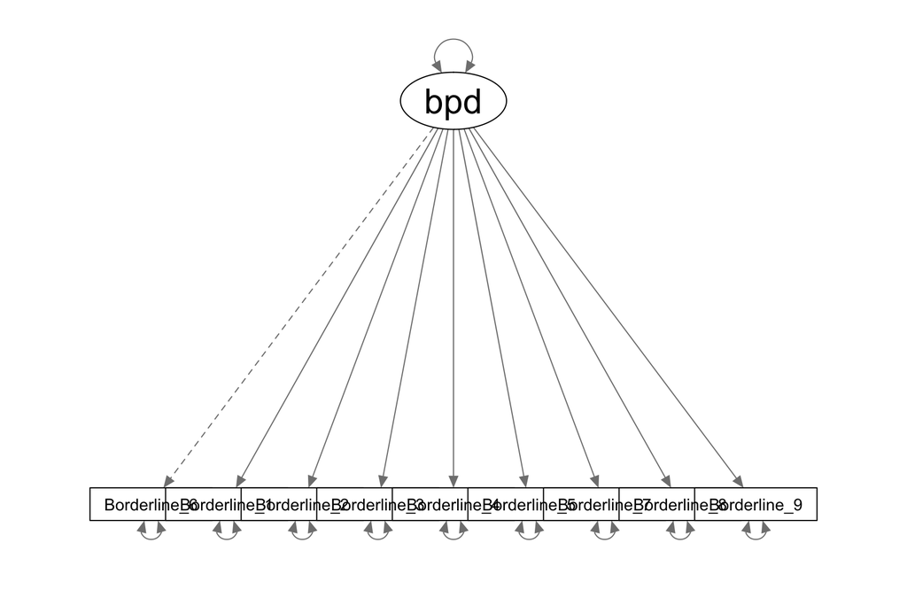

```r
semPaths_default(bpd_model)
```

```r
modificationindices(bpd_model, minimum.value = 5)
```

|  | lhs | op | rhs | mi | epc | sepc.lv | sepc.all | sepc.nox |
| --- | --- | --- | --- | --- | --- | --- | --- | --- |
| 20 | Borderline_6 | ~~ | Borderline_1 | 8.70 | -0.044 | -0.044 | -0.161 | -0.161 |
| 26 | Borderline_6 | ~~ | Borderline_8 | 15.97 | 0.073 | 0.073 | 0.228 | 0.228 |
| 29 | Borderline_1 | ~~ | Borderline_3 | 56.57 | 0.110 | 0.110 | 0.383 | 0.383 |
| 34 | Borderline_1 | ~~ | Borderline_9 | 21.58 | -0.049 | -0.049 | -0.231 | -0.231 |
| 38 | Borderline_2 | ~~ | Borderline_7 | 8.44 | -0.050 | -0.050 | -0.164 | -0.164 |
| 44 | Borderline_3 | ~~ | Borderline_8 | 35.88 | -0.106 | -0.106 | -0.316 | -0.316 |
| 49 | Borderline_4 | ~~ | Borderline_9 | 5.93 | -0.030 | -0.030 | -0.131 | -0.131 |
| 52 | Borderline_5 | ~~ | Borderline_9 | 13.72 | 0.036 | 0.036 | 0.197 | 0.197 |

```r
bpd_mod_syntax <- '
bpd =~ Borderline_6 + Borderline_1 + Borderline_2 + Borderline_3 + Borderline_4 + Borderline_5 + Borderline_7 + Borderline_8 + Borderline_9

Borderline_1 ~~ Borderline_3
'

bpd_model_mod <- sem(bpd_mod_syntax, estimator="MLR", allPD)
resid(bpd_model_mod, "cor")
```

```
## $type
## [1] "cor.bollen"
##
## $cov
##              Brdr_6 Brdr_1 Brdr_2 Brdr_3 Brdr_4 Brdr_5 Brdr_7 Brdr_8
## Borderline_6  0.000
## Borderline_1 -0.047  0.000
## Borderline_2 -0.023  0.058  0.000
## Borderline_3 -0.031  0.000  0.071  0.000
## Borderline_4  0.003  0.073 -0.018  0.064  0.000
## Borderline_5 -0.034  0.014  0.046 -0.023 -0.026  0.000
## Borderline_7  0.022  0.022 -0.063  0.020  0.004  0.012  0.000
## Borderline_8  0.072 -0.047  0.032 -0.156  0.029 -0.031 -0.014  0.000
## Borderline_9  0.016 -0.148 -0.038  0.045 -0.068  0.093  0.034 -0.036
##              Brdr_9
## Borderline_6
## Borderline_1
## Borderline_2
## Borderline_3
## Borderline_4
## Borderline_5
## Borderline_7
## Borderline_8
## Borderline_9  0.000
```

The maximum-likelihood approach assumes that indicators are normally distributed. But here, we have trichotmous data, which are unlikely to satisfy this assumption. The typical approach would be to estimate the model with an explicit categorical threshold structure that captures the distance between adjacent ordinal indicators.

```r
bpd_model_cat <- sem(bpd_only_syntax, estimator="WLSMV", allPD, ordered = paste0("Borderline_", 1:9))
summary(bpd_model_cat, fit.measures=TRUE)
```

```
## lavaan 0.6-3 ended normally after 21 iterations
##
##   Optimization method                           NLMINB
##   Number of free parameters                         27
##
##   Number of observations                           445
##
##   Estimator                                       DWLS      Robust
##   Model Fit Test Statistic                      72.056     108.554
##   Degrees of freedom                                27          27
##   P-value (Chi-square)                           0.000       0.000
##   Scaling correction factor                                  0.691
##   Shift parameter                                            4.238
##     for simple second-order correction (Mplus variant)
##
## Model test baseline model:
##
##   Minimum Function Test Statistic             3882.434    2611.156
##   Degrees of freedom                                36          36
##   P-value                                        0.000       0.000
##
## User model versus baseline model:
##
##   Comparative Fit Index (CFI)                    0.988       0.968
##   Tucker-Lewis Index (TLI)                       0.984       0.958
##
##   Robust Comparative Fit Index (CFI)                            NA
##   Robust Tucker-Lewis Index (TLI)                               NA
##
## Root Mean Square Error of Approximation:
##
##   RMSEA                                          0.061       0.082
##   90 Percent Confidence Interval          0.044  0.079       0.067  0.099
##   P-value RMSEA <= 0.05                          0.129       0.001
##
##   Robust RMSEA                                                  NA
##   90 Percent Confidence Interval                                NA     NA
##
## Standardized Root Mean Square Residual:
##
```

[output cut: 64 more lines]

```
##    .Borderline_8      0.519
##    .Borderline_9      0.507
##     bpd               0.699    0.053   13.154    0.000
##
## Scales y*:
##                    Estimate  Std.Err  z-value  P(>|z|)
##     Borderline_6      1.000
##     Borderline_1      1.000
##     Borderline_2      1.000
##     Borderline_3      1.000
##     Borderline_4      1.000
##     Borderline_5      1.000
##     Borderline_7      1.000
##     Borderline_8      1.000
##     Borderline_9      1.000
```

We still see some evidence of misfit.

```r
modificationIndices(bpd_model_cat, minimum.value = 5)
```

|  | lhs | op | rhs | mi | epc | sepc.lv | sepc.all | sepc.nox |
| --- | --- | --- | --- | --- | --- | --- | --- | --- |
| 66 | Borderline_1 | ~~ | Borderline_3 | 34.53 | 0.338 | 0.338 | 0.644 | 0.644 |
| 70 | Borderline_1 | ~~ | Borderline_8 | 5.07 | -0.177 | -0.177 | -0.313 | -0.313 |
| 71 | Borderline_1 | ~~ | Borderline_9 | 10.22 | -0.351 | -0.351 | -0.631 | -0.631 |
| 81 | Borderline_3 | ~~ | Borderline_8 | 13.50 | -0.280 | -0.280 | -0.579 | -0.579 |

The model suggests freeing conditional independence for some items. Here are the diagnostic criteria from DSM-IV

1. frantic efforts to avoid real or imagined abandonment.
2. a pattern of unstable and intense interpersonal relationships characterised by alternating between extremes of idealization and devaluation.
3. identity disturbance: markedly and persistently unstable self-image or sense of self.
4. impulsivity in at least two areas that are potentially self-damaging (e.g. spending, sex, substance abuse, reckless driving, binge eating). This does not include suicidal or self-harming behaviour.
5. recurrent suicidal behaviour, gestures, or threats, or self-mutilating behaviour.
6. affective instability due to a marked reactivity of mood - intense feelings that can last from a few hours to a few days.
7. chronic feelings of emptiness.
8. inappropriate intense anger or difficulty controlling anger.
9. transient, stress-related paranoid ideas or severe dissociative symptoms.